# General(ized) Linear Models: Partitioning Variance

## GLMs and Variance

> How much of the variation in the outcome variable is explained by the predictor variables?

[figure not shown]

## Multiple Regression Makes a Composite Variable

- Linear combination of predictor variables that is maximally correlated with outcome variable
- How well can you predict the outcome by the set of predictor variables?
  - correlation of y with \(\hat{y}\)
  - \(R^{2}\) = squared correlation coefficient of y with \(\hat{y}\)

## Milk Energy

```r
milk <- read_excel("../data/Milk.xlsx", na = "NA")
M <- milk %>%
  select(species, kcal.per.g, mass, neocortex.perc) %>%
  drop_na()
names(M) <- c("Species", "Milk_Energy", "Mass", "Neocortex")
M <- M %>% mutate(log_Mass = log(Mass))
```

## Visualizing data

[interactive chart not shown]

## Multivariate model

```r
fm_Multi <- lm(Milk_Energy ~ Neocortex + log_Mass, data = M)
summary(fm_Multi)
```

```
##
## Call:
## lm(formula = Milk_Energy ~ Neocortex + log_Mass, data = M)
##
## Residuals:
##       Min        1Q    Median        3Q       Max
## -0.250574 -0.039212  0.000633  0.072997  0.201985
##
## Coefficients:
##              Estimate Std. Error t value Pr(>|t|)
## (Intercept) -1.085254   0.515281  -2.106  0.05372 .
## Neocortex    0.027931   0.008015   3.485  0.00364 **
## log_Mass    -0.096402   0.024749  -3.895  0.00162 **
## ---
## Signif. codes:  0 '***' 0.001 '**' 0.01 '*' 0.05 '.' 0.1 ' ' 1
##
## Residual standard error: 0.1265 on 14 degrees of freedom
## Multiple R-squared:  0.5317, Adjusted R-squared:  0.4648
## F-statistic: 7.948 on 2 and 14 DF,  p-value: 0.004939
```

## \(R^{2}\): Multiple Regression Makes a Composite Variable

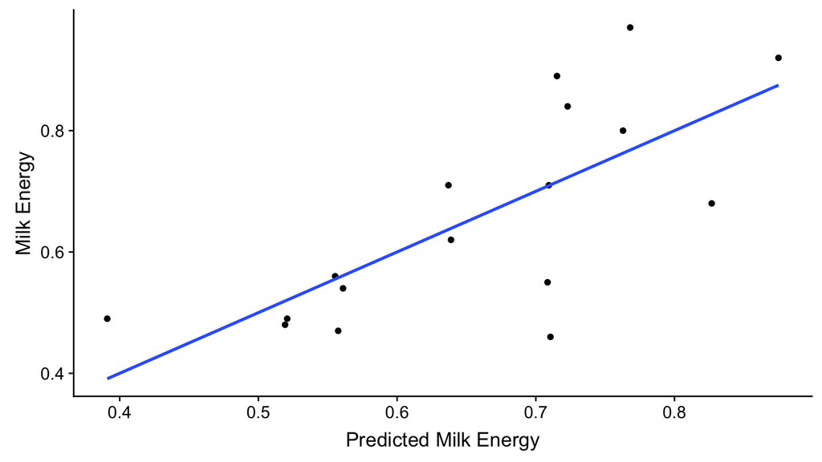

## \(R^{2}\): Multiple Regression Makes a Composite Variable

```r
cor(y_hat, M$Milk_Energy)^2
```

```
## [1] 0.5317037
```

```r
summary(fm_Multi)$r.squared
```

```
## [1] 0.5317037
```

## “Analysis of Variance”

Some total variability in *Y*:

1. Part explained by group membership
2. Part remains unexplained (“error” or “residual”)

\(F\)-statistic is the ratio of the two.

## Visualizing ANOVA

[figure not shown]

\[F = \frac{\mbox{Between Group Variation}}{\mbox{Within Group Variation}}\]

## Parts of an ANOVA table

```
## Analysis of Variance Table
##
## Response: Shift
##           Df Sum Sq Mean Sq F value   Pr(>F)
## Treatment  2 7.2245  3.6122  7.2894 0.004472 **
## Residuals 19 9.4153  0.4955
## ---
## Signif. codes:  0 '***' 0.001 '**' 0.01 '*' 0.05 '.' 0.1 ' ' 1
```

- `Sum Sq`: Variability accounted for by that part of the ANOVA
- `Mean Sq`: `Sum Sq` / `Df`
- `F value`: `Mean Sq` Treatment / `Mean Sq` Residual
- `Pr(>F)`: *P*-value for the *F*-test of that variable

## Role of variation

Large values of \(F\) are more likely to be significant.

\(F\) is a ratio:

\[F = \frac{\mbox{MS}_{group}}{\mbox{MS}_{error}}\]

What role does within vs. between group variation have in determining \(F\)?

## Intraclass Correlation Coefficient

For continuously varying measurements:

\[\mbox{ICC} =\frac{\sigma_{A}^{2}}{\sigma_{A}^{2}+MS_{error}}\]

\[\sigma_{A}^{2}=\frac{MS_{group}-MS_{error}}{n}\]

- \(n\) = Number of measurements per specimen (*not the sample size*).

Uses the results of the one-way ANOVA:

\[\mbox{Measurement} \sim \mbox{Specimen ID}\]

## Repeatability of caliper measurements

[figure not shown]

## Calculation of ICC

What is the ICC of repeated measurements of mouse bones?

```r
M <- read_excel("../data/G44_Morphometrics.xlsx")
glimpse(M)
```

```
## Observations: 119
## Variables: 15
## $ MouseID  <dbl> 46001, 46002, 46003, 46004, 46012, 46013, 46014, 46015,…
## $ Len1     <dbl> 16.22, 17.09, 16.78, 16.65, 16.85, 15.99, 16.08, 15.67,…
## $ Prox1    <dbl> 3.76, 3.92, 3.66, 3.52, 3.67, 3.55, 3.44, 3.63, 3.70, 3…
## $ Dist1    <dbl> 3.44, 3.17, 2.93, 3.05, 2.92, 2.80, 2.91, 2.78, 3.06, 2…
## $ AP1      <dbl> 1.38, 1.44, 1.37, 1.38, 1.39, 1.23, 1.32, 1.34, 1.32, 1…
## $ ML1      <dbl> 1.67, 1.87, 1.88, 1.79, 1.65, 1.57, 1.57, 1.46, 1.80, 1…
## $ HeadHt1  <dbl> 1.61, 1.46, 1.37, 1.40, 1.35, 1.36, 1.33, 1.24, 1.38, 1…
## $ HeadDep1 <dbl> 1.58, 1.56, 1.58, 1.58, 1.51, 1.44, 1.51, 1.43, 1.49, 1…
## $ Len2     <dbl> 16.21, 17.08, 16.78, 16.65, 16.86, 15.99, 16.08, 15.68,…
## $ Prox2    <dbl> 3.75, 3.90, 3.65, 3.54, 3.66, 3.54, 3.45, 3.62, 3.69, 3…
## $ Dist2    <dbl> 3.44, 3.16, 2.94, 3.05, 2.92, 2.82, 2.90, 2.76, 3.05, 2…
## $ AP2      <dbl> 1.38, 1.43, 1.37, 1.37, 1.39, 1.24, 1.31, 1.34, 1.31, 1…
## $ ML2      <dbl> 1.68, 1.87, 1.87, 1.79, 1.66, 1.56, 1.57, 1.46, 1.78, 1…
## $ HeadHt2  <dbl> 1.58, 1.45, 1.38, 1.38, 1.35, 1.37, 1.34, 1.22, 1.39, 1…
## $ HeadDep2 <dbl> 1.59, 1.59, 1.59, 1.49, 1.52, 1.45, 1.53, 1.42, 1.49, 1…
```

## Pairs of measurements

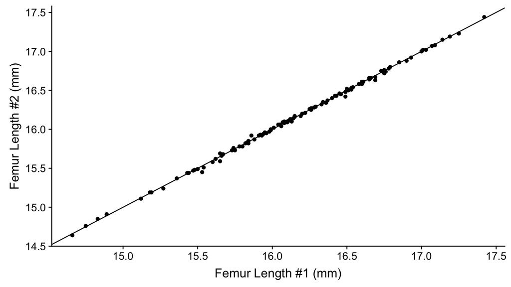

## Data processing

Want two columns: (1) measurement and (2) ID as a factor.

```r
Lengths <- data.frame(Fem_Len = c(M$Len1, M$Len2),
                      MouseID = factor(c(M$MouseID, M$MouseID)))
Lengths <- Lengths %>% drop_na()
glimpse(Lengths)
```

```
## Observations: 238
## Variables: 2
## $ Fem_Len <dbl> 16.22, 17.09, 16.78, 16.65, 16.85, 15.99, 16.08, 15.67, …
## $ MouseID <fct> 46001, 46002, 46003, 46004, 46012, 46013, 46014, 46015, …
```

## ICC via ANOVA

```r
fm <- anova(lm(Fem_Len ~ MouseID, data = Lengths))
print(fm, digits = 5)
```

```
## Analysis of Variance Table
##
## Response: Fem_Len
##            Df Sum Sq Mean Sq F value    Pr(>F)
## MouseID   118 75.023 0.63579  3510.8 < 2.2e-16 ***
## Residuals 119  0.022 0.00018
## ---
## Signif. codes:  0 '***' 0.001 '**' 0.01 '*' 0.05 '.' 0.1 ' ' 1
```

```r
var_a <- (0.63579 - 0.00018) / 2
var_a / (var_a + 0.00018)
```

```
## [1] 0.9994339
```

ICC is 0.999 for these measurements.

## Examples of Applications of Variance Component Estimation

- Quantitative genetics
  - especially heritabilities, genetic correlations etc.
- Repeatability

[figure not shown]

## Quiz 08-1

Watch Lecture 08-2